# Lab 02: Matrix Decompositions

Donggyun Kim

27008257

1/31/2018

# 1) Singular Value Decomposition

$$\mathbf{M} = \mathbf{UDV^\top}$$

- $\mathbf{M}$: $n \times p$ matrix of full column-rank $p$, $(n > p)$
- $\mathbf{U}$: $n \times p$ matrix of left singular vectors
- $\mathbf{D}$: $p \times p$ diagonal matrix of singular values
- $\mathbf{V}$: $p \times p$ matrix of right sungular vectors
1. Use `svd()` to compute SVD of state.x77

```r
SVD <- svd(state.x77)
SVD
```

```
## $d
## [1] 7.796059e+05 4.165429e+04 1.720272e+04 3.248188e+02 6.770037e+01
## [6] 3.951165e+01 1.722726e+01 2.035865e+00
##
## $u
##               [,1]          [,2]        [,3]          [,4]         [,5]
##  [1,] -0.065243264 -0.0729561146 -0.06152569 -0.2002048703  0.184378208
##  [2,] -0.726286309  0.3996986401  0.14515821 -0.0256494217 -0.285416558
##  [3,] -0.145609572  0.0006988312 -0.09138632 -0.3078964817  0.039868675
##  [4,] -0.066770994 -0.0366594379 -0.08413430 -0.0611776212  0.241744229
##  [5,] -0.201296899 -0.3834073503  0.37442094 -0.0663952937  0.013785388
##  [6,] -0.133262266 -0.0180699696 -0.11033529  0.1293094858 -0.039372946
##  [7,] -0.006521775 -0.1171220320 -0.20325030  0.0026713794 -0.255755765
##  [8,] -0.002728724 -0.0591476168 -0.23834782 -0.0971115928 -0.137579213
##  [9,] -0.069772724 -0.1837132343 -0.00836565 -0.2649047243 -0.062929493
```

[output cut: 112 more lines]

2. Create the matrices, $\mathbf{U}$, $\mathbf{D}$, and $\mathbf{V}$

```r
U <- SVD$u
U
```

```
##               [,1]          [,2]        [,3]          [,4]         [,5]
##  [1,] -0.065243264 -0.0729561146 -0.06152569 -0.2002048703  0.184378208
##  [2,] -0.726286309  0.3996986401  0.14515821 -0.0256494217 -0.285416558
##  [3,] -0.145609572  0.0006988312 -0.09138632 -0.3078964817  0.039868675
##  [4,] -0.066770994 -0.0366594379 -0.08413430 -0.0611776212  0.241744229
##  [5,] -0.201296899 -0.3834073503  0.37442094 -0.0663952937  0.013785388
##  [6,] -0.133262266 -0.0180699696 -0.11033529  0.1293094858 -0.039372946
##  [7,] -0.006521775 -0.1171220320 -0.20325030  0.0026713794 -0.255755765
##  [8,] -0.002728724 -0.0591476168 -0.23834782 -0.0971115928 -0.137579213
##  [9,] -0.069772724 -0.1837132343 -0.00836565 -0.2649047243 -0.062929493
## [10,] -0.074743227 -0.1002080267 -0.04816986 -0.0990103159  0.036983462
## [11,] -0.008438551 -0.0632789557 -0.23561282 -0.4222250694 -0.071998808
## [12,] -0.106146928  0.0097388251 -0.12935001  0.0470730412  0.140565477
## [13,] -0.072003847 -0.2489450080  0.04831540  0.1080649321 -0.161983453
## [14,] -0.046599868 -0.1304935186 -0.07660339  0.0639767938 -0.002978962
```

[output cut: 87 more lines]

```r
D <- diag(SVD$d)
D
```

```
##          [,1]     [,2]     [,3]     [,4]     [,5]     [,6]     [,7]
## [1,] 779605.9     0.00     0.00   0.0000  0.00000  0.00000  0.00000
## [2,]      0.0 41654.29     0.00   0.0000  0.00000  0.00000  0.00000
## [3,]      0.0     0.00 17202.72   0.0000  0.00000  0.00000  0.00000
## [4,]      0.0     0.00     0.00 324.8188  0.00000  0.00000  0.00000
## [5,]      0.0     0.00     0.00   0.0000 67.70037  0.00000  0.00000
## [6,]      0.0     0.00     0.00   0.0000  0.00000 39.51165  0.00000
## [7,]      0.0     0.00     0.00   0.0000  0.00000  0.00000 17.22726
## [8,]      0.0     0.00     0.00   0.0000  0.00000  0.00000  0.00000
##          [,8]
## [1,] 0.000000
## [2,] 0.000000
## [3,] 0.000000
## [4,] 0.000000
## [5,] 0.000000
## [6,] 0.000000
## [7,] 0.000000
## [8,] 2.035865
```

```r
V <- SVD$v
V
```

```
##               [,1]          [,2]          [,3]          [,4]          [,5]
## [1,] -2.550770e-02 -0.9082092932  0.4177118118  4.679182e-03  2.803094e-04
## [2,] -2.741509e-02 -0.4169303207 -0.9078444028 -2.889047e-02 -1.956143e-02
## [3,] -7.149741e-06 -0.0001114962 -0.0001923048 -7.018767e-03  3.915118e-02
## [4,] -4.125144e-04 -0.0066594026 -0.0150487962  5.436391e-03  8.991792e-01
## [5,] -4.884947e-05 -0.0007614284 -0.0009154506 -2.776271e-02  1.846756e-01
## [6,] -3.283506e-04 -0.0047064823 -0.0113669749  2.825484e-02  3.941200e-01
## [7,] -6.304407e-04 -0.0076591124 -0.0278417410  9.987470e-01 -1.120269e-02
## [8,] -9.992983e-01  0.0346299666  0.0142713208  3.293833e-05  2.657452e-05
##               [,6]          [,7]          [,8]
## [1,]  0.0002944589  1.373923e-04 -2.384239e-05
## [2,] -0.0043281262 -1.251878e-04 -5.972863e-05
## [3,] -0.0643656867 -2.954433e-02 -9.966956e-01
## [4,] -0.3090387777  3.058412e-01  4.617762e-02
## [5,] -0.3580525433 -9.130165e-01  5.763660e-02
## [6,]  0.8780641235 -2.675847e-01 -3.348758e-02
## [7,] -0.0336904151 -1.968622e-02 -4.707792e-03
## [8,] -0.0000105016  1.886104e-05  1.471978e-06
```

3. Confirm that the data state.x77 can be obtained as the product of: $\mathbf{UDV^\top}$

```r
UDtV <- U %*% D %*% t(V)

head(UDtV, 10)
```

```
##        [,1] [,2] [,3]  [,4] [,5] [,6] [,7]   [,8]
##  [1,]  3615 3624  2.1 69.05 15.1 41.3   20  50708
##  [2,]   365 6315  1.5 69.31 11.3 66.7  152 566432
##  [3,]  2212 4530  1.8 70.55  7.8 58.1   15 113417
##  [4,]  2110 3378  1.9 70.66 10.1 39.9   65  51945
##  [5,] 21198 5114  1.1 71.71 10.3 62.6   20 156361
##  [6,]  2541 4884  0.7 72.06  6.8 63.9  166 103766
##  [7,]  3100 5348  1.1 72.48  3.1 56.0  139   4862
##  [8,]   579 4809  0.9 70.06  6.2 54.6  103   1982
##  [9,]  8277 4815  1.3 70.66 10.7 52.6   11  54090
## [10,]  4931 4091  2.0 68.54 13.9 40.6   60  58073
```

```r
head(state.x77, 10)
```

```
##             Population Income Illiteracy Life Exp Murder HS Grad Frost
## Alabama           3615   3624        2.1    69.05   15.1    41.3    20
## Alaska             365   6315        1.5    69.31   11.3    66.7   152
## Arizona           2212   4530        1.8    70.55    7.8    58.1    15
## Arkansas          2110   3378        1.9    70.66   10.1    39.9    65
## California       21198   5114        1.1    71.71   10.3    62.6    20
## Colorado          2541   4884        0.7    72.06    6.8    63.9   166
## Connecticut       3100   5348        1.1    72.48    3.1    56.0   139
## Delaware           579   4809        0.9    70.06    6.2    54.6   103
## Florida           8277   4815        1.3    70.66   10.7    52.6    11
## Georgia           4931   4091        2.0    68.54   13.9    40.6    60
##               Area
## Alabama      50708
## Alaska      566432
## Arizona     113417
## Arkansas     51945
## California  156361
## Colorado    103766
## Connecticut   4862
## Delaware      1982
## Florida      54090
## Georgia      58073
```

**SVD and best Rank-one Approximations**
$$\mathbf{X_r} = \displaystyle \sum_{k = 1}^r l_k\mathbf{u}_k{\mathbf{v}_k}^t$$
1) Create an object state2 by selecting the first five columns of state.x77

```r
state2 <- state.x77[, 1:5]
head(state2, 10)
```

```
##             Population Income Illiteracy Life Exp Murder
## Alabama           3615   3624        2.1    69.05   15.1
## Alaska             365   6315        1.5    69.31   11.3
## Arizona           2212   4530        1.8    70.55    7.8
## Arkansas          2110   3378        1.9    70.66   10.1
## California       21198   5114        1.1    71.71   10.3
## Colorado          2541   4884        0.7    72.06    6.8
## Connecticut       3100   5348        1.1    72.48    3.1
## Delaware           579   4809        0.9    70.06    6.2
## Florida           8277   4815        1.3    70.66   10.7
## Georgia           4931   4091        2.0    68.54   13.9
```

2. Perform the SVD decomposition of state2

```r
SVD_2 <- svd(state2)
SVD_2
```

```
## $d
## [1] 50045.791571 19396.967009    66.375214    23.998595     2.751534
##
## $u
##              [,1]        [,2]         [,3]        [,4]         [,5]
##  [1,] -0.09997135  0.05588134  0.207803986 -0.27948006  0.059645780
##  [2,] -0.07458226  0.26330472 -0.449132534 -0.37479294 -0.136034032
##  [3,] -0.08624004  0.13435300 -0.010958299 -0.05947081 -0.213664628
##  [4,] -0.07204228  0.08731975  0.272204701 -0.06454102 -0.037382329
##  [5,] -0.41127018 -0.37133749 -0.085540963  0.07503913  0.025101816
##  [6,] -0.09559963  0.14048243 -0.076126534 -0.02410565  0.116745567
##  [7,] -0.11001198  0.14494201 -0.190073693  0.09963613 -0.228952748
##  [8,] -0.06185214  0.19210442 -0.093590778 -0.03918152  0.018031448
##  [9,] -0.19113654 -0.02292485 -0.056128961 -0.11029182  0.039630988
## [10,] -0.12712317  0.03929931  0.088057446 -0.25213413 -0.010192169
```

[output cut: 48 more lines]

3. Confirm that the sum: $\displaystyle\sum_{k=1}^5l_k\mathbf{u}_k\mathbf{v}_k^t$ equals state2

```r
l <- SVD_2$d
U <- SVD_2$u
V <- SVD_2$v

X <- matrix(0, nrow = nrow(state2), ncol = ncol(state2))
for (i in 1:length(l)) {
  X <- X + l[i] * U[, i] %*% t(V[, i])
}

head(X, 10)
```

```
##        [,1] [,2] [,3]  [,4] [,5]
##  [1,]  3615 3624  2.1 69.05 15.1
##  [2,]   365 6315  1.5 69.31 11.3
##  [3,]  2212 4530  1.8 70.55  7.8
##  [4,]  2110 3378  1.9 70.66 10.1
##  [5,] 21198 5114  1.1 71.71 10.3
##  [6,]  2541 4884  0.7 72.06  6.8
##  [7,]  3100 5348  1.1 72.48  3.1
##  [8,]   579 4809  0.9 70.06  6.2
##  [9,]  8277 4815  1.3 70.66 10.7
## [10,]  4931 4091  2.0 68.54 13.9
```

```r
head(state2, 10)
```

```
##             Population Income Illiteracy Life Exp Murder
## Alabama           3615   3624        2.1    69.05   15.1
## Alaska             365   6315        1.5    69.31   11.3
## Arizona           2212   4530        1.8    70.55    7.8
## Arkansas          2110   3378        1.9    70.66   10.1
## California       21198   5114        1.1    71.71   10.3
## Colorado          2541   4884        0.7    72.06    6.8
## Connecticut       3100   5348        1.1    72.48    3.1
## Delaware           579   4809        0.9    70.06    6.2
## Florida           8277   4815        1.3    70.66   10.7
## Georgia           4931   4091        2.0    68.54   13.9
```

**Using SVD output to visualize data**

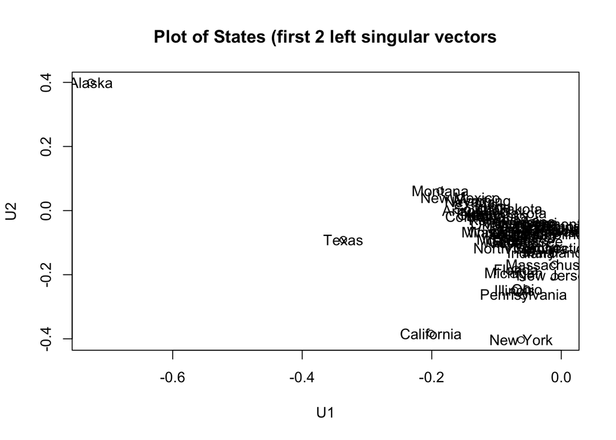

```r
library(ggplot2)

U <- svd(state.x77)$u
U1 <- U[, 1]
U2 <- U[, 2]

plot(U1, U2, main = "Plot of States (first 2 left singular vectors")
text(U1, U2, rownames(state.x77))
```

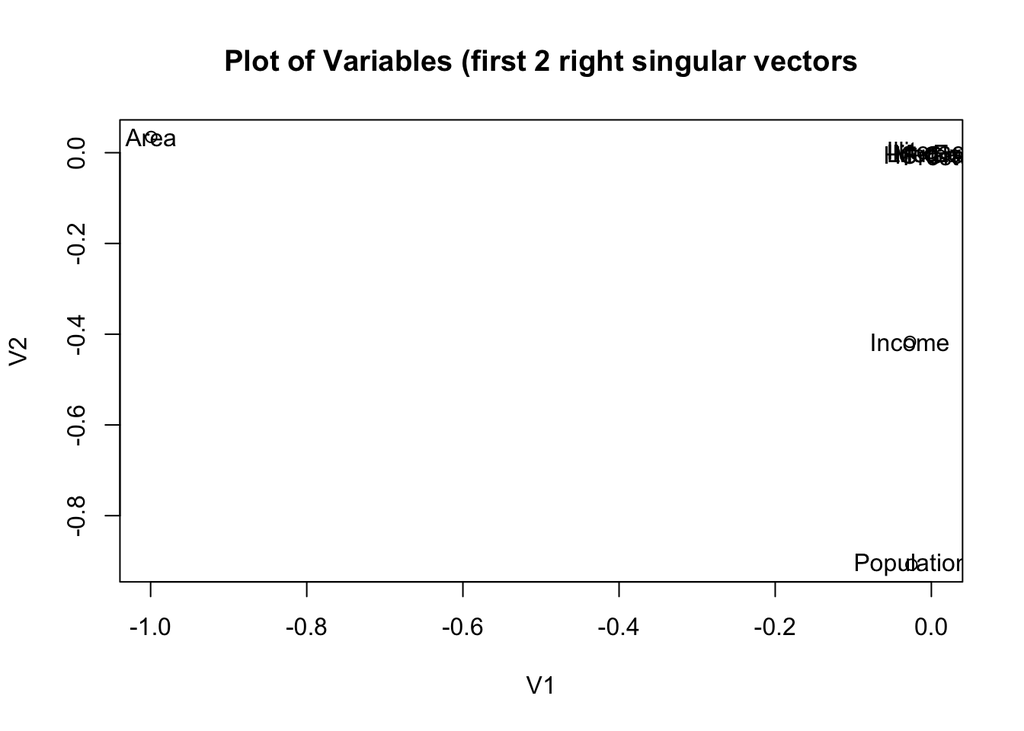

```r
V <- svd(state.x77)$v

V1 <- V[, 1]
V2 <- V[, 2]

plot(V1, V2, main = "Plot of Variables (first 2 right singular vectors")
text(V1, V2, colnames(state.x77))
```

# 2) Eigenvalue Decomposition

1. Compute a matrix X as the mean-centerd data of state.x77

```r
X <- sweep(state.x77, 2, colMeans(state.x77), "-")
head(X, 10)
```

```
##             Population  Income Illiteracy Life Exp Murder HS Grad  Frost
## Alabama        -631.42  -811.8       0.93  -1.8286  7.722 -11.808 -84.46
## Alaska        -3881.42  1879.2       0.33  -1.5686  3.922  13.592  47.54
## Arizona       -2034.42    94.2       0.63  -0.3286  0.422   4.992 -89.46
## Arkansas      -2136.42 -1057.8       0.73  -0.2186  2.722 -13.208 -39.46
## California    16951.58   678.2      -0.07   0.8314  2.922   9.492 -84.46
## Colorado      -1705.42   448.2      -0.47   1.1814 -0.578  10.792  61.54
## Connecticut   -1146.42   912.2      -0.07   1.6014 -4.278   2.892  34.54
## Delaware      -3667.42   373.2      -0.27  -0.8186 -1.178   1.492  -1.46
## Florida        4030.58   379.2       0.13  -0.2186  3.322  -0.508 -93.46
## Georgia         684.58  -344.8       0.83  -2.3386  6.522 -12.508 -44.46
##                  Area
## Alabama     -20027.88
## Alaska      495696.12
## Arizona      42681.12
## Arkansas    -18790.88
## California   85625.12
## Colorado     33030.12
## Connecticut -65873.88
## Delaware    -68753.88
## Florida     -16645.88
## Georgia     -12662.88
```

2. Calculate the sum-of-sqares and cross-products matrix $\mathbf{S} = \mathbf{X}^\top\mathbf{X}$

```r
S <- crossprod(as.matrix(X))
S
```

```
##              Population       Income  Illiteracy     Life Exp       Murder
## Population 976652504.18  27990259.20  14350.5300  -19984.2806  277512.6620
## Income      27990259.20  18501092.00  -8021.4000   13752.4960  -25572.8200
## Illiteracy     14350.53     -8021.40     18.2050     -23.5941      77.5070
## Life Exp      -19984.28     13752.50    -23.5941      88.2990    -189.6045
## Murder        277512.66    -25572.82     77.5070    -189.6045     667.7458
## HS Grad      -174023.97    150761.68   -158.5380     309.3216    -712.9312
## Frost       -3777016.66    354152.60  -1043.2100     896.0522   -5066.8940
## Area       420807930.52 933401673.80 196898.5200 -602411.0084 3525081.0680
##                  HS Grad         Frost          Area
## Population  -174023.9680 -3777016.6600  4.208079e+08
## Income       150761.6800   354152.6000  9.334017e+08
## Illiteracy     -158.5380    -1043.2100  1.968985e+05
## Life Exp        309.3216      896.0522 -6.024110e+05
## Murder         -712.9312    -5066.8940  3.525081e+06
## HS Grad        3196.6568     7545.6160  1.126379e+07
## Frost          7545.6160   132398.4200  1.287249e+07
## Area       11263786.4480 12872490.7600  3.567567e+11
```

3. Confirm that cov($\mathbf{X}$) is equal to $\frac{1}{n - 1}\mathbf{X}^\top\mathbf{X}$

```r
n <- nrow(state.x77)
S / (n - 1)
```

```
##               Population        Income   Illiteracy      Life Exp
## Population 19931683.7588   571229.7796  292.8679592 -4.078425e+02
## Income       571229.7796   377573.3061 -163.7020408  2.806632e+02
## Illiteracy      292.8680     -163.7020    0.3715306 -4.815122e-01
## Life Exp       -407.8425      280.6632   -0.4815122  1.802020e+00
## Murder         5663.5237     -521.8943    1.5817755 -3.869480e+00
## HS Grad       -3551.5096     3076.7690   -3.2354694  6.312685e+00
## Frost        -77081.9727     7227.6041  -21.2900000  1.828678e+01
## Area        8587916.9494 19049013.7510 4018.3371429 -1.229410e+04
##                  Murder       HS Grad        Frost          Area
## Population  5663.523714  -3551.509551 -77081.97265  8.587917e+06
## Income      -521.894286   3076.768980   7227.60408  1.904901e+07
## Illiteracy     1.581776     -3.235469    -21.29000  4.018337e+03
## Life Exp      -3.869480      6.312685     18.28678 -1.229410e+04
## Murder        13.627465    -14.549616   -103.40600  7.194043e+04
## HS Grad      -14.549616     65.237894    153.99216  2.298732e+05
## Frost       -103.406000    153.992163   2702.00857  2.627039e+05
## Area       71940.429959 229873.192816 262703.89306  7.280748e+09
```

```r
cov(X)
```

```
##               Population        Income   Illiteracy      Life Exp
## Population 19931683.7588   571229.7796  292.8679592 -4.078425e+02
## Income       571229.7796   377573.3061 -163.7020408  2.806632e+02
## Illiteracy      292.8680     -163.7020    0.3715306 -4.815122e-01
## Life Exp       -407.8425      280.6632   -0.4815122  1.802020e+00
## Murder         5663.5237     -521.8943    1.5817755 -3.869480e+00
## HS Grad       -3551.5096     3076.7690   -3.2354694  6.312685e+00
## Frost        -77081.9727     7227.6041  -21.2900000  1.828678e+01
## Area        8587916.9494 19049013.7510 4018.3371429 -1.229410e+04
##                  Murder       HS Grad        Frost          Area
## Population  5663.523714  -3551.509551 -77081.97265  8.587917e+06
## Income      -521.894286   3076.768980   7227.60408  1.904901e+07
## Illiteracy     1.581776     -3.235469    -21.29000  4.018337e+03
## Life Exp      -3.869480      6.312685     18.28678 -1.229410e+04
## Murder        13.627465    -14.549616   -103.40600  7.194043e+04
## HS Grad      -14.549616     65.237894    153.99216  2.298732e+05
## Frost       -103.406000    153.992163   2702.00857  2.627039e+05
## Area       71940.429959 229873.192816 262703.89306  7.280748e+09
```

4. Use `solve()` to compute the inverse $\mathbf{S}^{-1}$

```r
solve(S)
```

```
##               Population        Income    Illiteracy      Life Exp
## Population  1.650948e-09 -4.307555e-09  5.225742e-06 -2.223465e-06
## Income     -4.307555e-09  1.077265e-07  1.547675e-05  9.359192e-07
## Illiteracy  5.225742e-06  1.547675e-05  2.419140e-01 -1.451694e-03
## Life Exp   -2.223465e-06  9.359192e-07 -1.451694e-03  4.292373e-02
## Murder     -1.468652e-06  1.243483e-06 -1.072465e-02  1.292533e-02
## HS Grad     3.275750e-07 -3.681189e-06  7.733845e-03 -2.100236e-03
## Frost       3.944094e-08 -2.063633e-08  1.207855e-03  2.461676e-04
## Area        5.430157e-12 -1.790480e-10 -3.644146e-07  3.169130e-09
##                   Murder       HS Grad         Frost          Area
## Population -1.468652e-06  3.275750e-07  3.944094e-08  5.430157e-12
## Income      1.243483e-06 -3.681189e-06 -2.063633e-08 -1.790480e-10
## Illiteracy -1.072465e-02  7.733845e-03  1.207855e-03 -3.644146e-07
## Life Exp    1.292533e-02 -2.100236e-03  2.461676e-04  3.169130e-09
## Murder      7.810481e-03 -2.525777e-04  1.006308e-04 -4.660764e-08
## HS Grad    -2.525777e-04  1.083440e-03  2.596521e-05 -3.121827e-08
## Frost       1.006308e-04  2.596521e-05  1.922321e-05 -2.751216e-09
## Area       -4.660764e-08 -3.121827e-08 -2.751216e-09  5.016997e-12
```

5. USE `eigent()` to compute the EVD of $\mathbf{S} = \mathbf{V \Lambda V}^\top$

```r
EVD <- eigen(S)
EVD
```

```
## eigen() decomposition
## $values
## [1] 3.567596e+11 9.769219e+08 1.531954e+07 1.055004e+05 1.789433e+03
## [6] 2.968959e+02 2.121607e+01 4.120647e+00
##
## $vectors
##               [,1]          [,2]          [,3]          [,4]          [,5]
## [1,] -1.182966e-03  9.996005e-01  0.0278490777 -4.671254e-03  3.349393e-04
## [2,] -2.616550e-03  2.796866e-02 -0.9991766328  2.821732e-02 -7.792882e-03
## [3,] -5.518945e-07  1.420515e-05  0.0005844687  7.100747e-03 -4.054743e-02
## [4,]  1.688521e-06 -1.928393e-05 -0.0010367078 -3.875966e-03  1.193295e-01
## [5,] -9.881522e-06  2.787128e-04  0.0027764911  2.816092e-02 -2.386638e-01
## [6,] -3.157288e-05 -1.882545e-04 -0.0082661337 -2.784545e-02  9.622385e-01
## [7,] -3.607163e-05 -3.871630e-03 -0.0280421226 -9.987733e-01 -3.452920e-02
## [8,] -9.999959e-01 -1.255538e-03  0.0025827049 -3.168841e-05 -6.558672e-06
##               [,6]          [,7]          [,8]
## [1,]  1.386661e-04 -5.183454e-05  2.191850e-05
## [2,] -1.119562e-04  3.850506e-05  6.290403e-05
## [3,] -3.091522e-02  2.550656e-02  9.983480e-01
## [4,]  2.855357e-01  9.508427e-01 -1.057617e-02
## [5,] -9.200852e-01  3.058552e-01 -4.620107e-02
## [6,] -2.656351e-01 -4.075556e-02  3.209925e-02
## [7,] -1.986814e-02  6.252701e-03  4.942864e-03
## [8,]  1.882356e-05 -4.090819e-07 -1.494594e-06
```

6. Confirm that $\mathbf{S}^{-1}$ can also be obtained as: $\mathbf{V}\mathbf{\Lambda}^{-1}\mathbf{V}^\top$

```r
V <- EVD$vectors
L <- diag(EVD$values)

V %*% solve(L) %*% t(V)
```

```
##               [,1]          [,2]          [,3]          [,4]          [,5]
## [1,]  1.650948e-09 -4.307555e-09  5.225742e-06 -2.223465e-06 -1.468652e-06
## [2,] -4.307555e-09  1.077265e-07  1.547675e-05  9.359192e-07  1.243483e-06
## [3,]  5.225742e-06  1.547675e-05  2.419140e-01 -1.451694e-03 -1.072465e-02
## [4,] -2.223465e-06  9.359192e-07 -1.451694e-03  4.292373e-02  1.292533e-02
## [5,] -1.468652e-06  1.243483e-06 -1.072465e-02  1.292533e-02  7.810481e-03
## [6,]  3.275750e-07 -3.681189e-06  7.733845e-03 -2.100236e-03 -2.525777e-04
## [7,]  3.944094e-08 -2.063633e-08  1.207855e-03  2.461676e-04  1.006308e-04
## [8,]  5.430157e-12 -1.790480e-10 -3.644146e-07  3.169130e-09 -4.660764e-08
##               [,6]          [,7]          [,8]
## [1,]  3.275750e-07  3.944094e-08  5.430157e-12
## [2,] -3.681189e-06 -2.063633e-08 -1.790480e-10
## [3,]  7.733845e-03  1.207855e-03 -3.644146e-07
## [4,] -2.100236e-03  2.461676e-04  3.169130e-09
## [5,] -2.525777e-04  1.006308e-04 -4.660764e-08
## [6,]  1.083440e-03  2.596521e-05 -3.121827e-08
## [7,]  2.596521e-05  1.922321e-05 -2.751216e-09
## [8,] -3.121827e-08 -2.751216e-09  5.016997e-12
```

```r
solve(S)
```

```
##               Population        Income    Illiteracy      Life Exp
## Population  1.650948e-09 -4.307555e-09  5.225742e-06 -2.223465e-06
## Income     -4.307555e-09  1.077265e-07  1.547675e-05  9.359192e-07
## Illiteracy  5.225742e-06  1.547675e-05  2.419140e-01 -1.451694e-03
## Life Exp   -2.223465e-06  9.359192e-07 -1.451694e-03  4.292373e-02
## Murder     -1.468652e-06  1.243483e-06 -1.072465e-02  1.292533e-02
## HS Grad     3.275750e-07 -3.681189e-06  7.733845e-03 -2.100236e-03
## Frost       3.944094e-08 -2.063633e-08  1.207855e-03  2.461676e-04
## Area        5.430157e-12 -1.790480e-10 -3.644146e-07  3.169130e-09
##                   Murder       HS Grad         Frost          Area
## Population -1.468652e-06  3.275750e-07  3.944094e-08  5.430157e-12
## Income      1.243483e-06 -3.681189e-06 -2.063633e-08 -1.790480e-10
## Illiteracy -1.072465e-02  7.733845e-03  1.207855e-03 -3.644146e-07
## Life Exp    1.292533e-02 -2.100236e-03  2.461676e-04  3.169130e-09
## Murder      7.810481e-03 -2.525777e-04  1.006308e-04 -4.660764e-08
## HS Grad    -2.525777e-04  1.083440e-03  2.596521e-05 -3.121827e-08
## Frost       1.006308e-04  2.596521e-05  1.922321e-05 -2.751216e-09
## Area       -4.660764e-08 -3.121827e-08 -2.751216e-09  5.016997e-12
```

**Power Method**

```r
A <- matrix(c(5, -14, 11, -4, 4, -4, 3, 6, -3), nrow = 3, byrow = 1)
w0 <- c(1, 1, 1)

eig <- function(X, v, k) {
  for (i in 1:k) {
    v_p <- X %*% v
    v_c <- v_p / max(abs(v_p))
    v <- v_c
  }
  val <- as.numeric(crossprod(v, X) %*% v / crossprod(v, v))
  eig <- list(val, v)
  names(eig) <- c("value", "vector")
  eig
}

eig(A, w0, 10)
```

```
## $value
## [1] 11.97889
##
## $vector
##              [,1]
## [1,]  1.000000000
## [2,] -0.499268649
## [3,] -0.001462701
```

```r
eigen(A)
```

```
## eigen() decomposition
## $values
## [1]  1.200000e+01 -6.000000e+00  4.930713e-16
##
## $vectors
##               [,1]          [,2]       [,3]
## [1,] -8.944272e-01  7.071068e-01 -0.2672612
## [2,]  4.472136e-01  1.040834e-16  0.5345225
## [3,] -5.945103e-17 -7.071068e-01  0.8017837
```

**$l_p$ norm for Power Method**

```r
eig <- function(X, v, k, norm = Inf) {
  for (i in 1:k) {
    v_p <- X %*% v
    if (norm == Inf) {
      nm <- max(abs(v_p))
    } else {
      nm <- (sum(abs(v_p)^norm))^(1/norm)
    }
    v_c <- v_p / nm
    v <- v_c
  }
  val <- as.numeric(crossprod(v, X) %*% v / crossprod(v, v))
  eig <- list(val, v)
  names(eig) <- c("value", "vector")
  eig
}

eig(A, w0, 20)  # l-infinity norm
```

```
## $value
## [1] 11.99998
##
## $vector
##               [,1]
## [1,]  1.000000e+00
## [2,] -4.999993e-01
## [3,] -1.430509e-06
```

```r
eig(A, w0, 20, 2)  # l-2 norm
```

```
## $value
## [1] 11.99998
##
## $vector
##               [,1]
## [1,]  8.944274e-01
## [2,] -4.472131e-01
## [3,] -1.279487e-06
```

```r
eigen(A)
```

```
## eigen() decomposition
## $values
## [1]  1.200000e+01 -6.000000e+00  4.930713e-16
##
## $vectors
##               [,1]          [,2]       [,3]
## [1,] -8.944272e-01  7.071068e-01 -0.2672612
## [2,]  4.472136e-01  1.040834e-16  0.5345225
## [3,] -5.945103e-17 -7.071068e-01  0.8017837
```

**Deflation and more eigenvectors**

```r
deflation <- function(X, v, k, norm = Inf) {

  eig <- eig(X, v, k, norm)
  def <- list(eig$value, eig$vector)
  names(def) <- c("values", "vectors")

  for(i in 2:nrow(X)) {
  X <- X - eig$value * tcrossprod(eig$vector)
  eig <- eig(X, v, k, norm)
  def$values <- c(def$values, eig$value)
  def$vectors <- cbind(def$vectors, eig$vector)
  }
  def
}

deflation(A, w0, 20, 2)
```

```
## $values
## [1]  1.199998e+01 -6.000041e+00  6.234112e-05
##
## $vectors
##               [,1]       [,2]       [,3]
## [1,]  8.944274e-01  0.8970847  0.8970854
## [2,] -4.472131e-01 -0.2760246 -0.2760268
## [3,] -1.279487e-06 -0.3450355 -0.3450319
```

```r
eigen(A)
```

```
## eigen() decomposition
## $values
## [1]  1.200000e+01 -6.000000e+00  4.930713e-16
##
## $vectors
##               [,1]          [,2]       [,3]
## [1,] -8.944272e-01  7.071068e-01 -0.2672612
## [2,]  4.472136e-01  1.040834e-16  0.5345225
## [3,] -5.945103e-17 -7.071068e-01  0.8017837
```